# Rusundersøkelse 2025

Gjennomgang av datasettet fra SSB

2025-11-12

# Data report overview

The dataset examined has the following dimensions:

| Feature | Result |
| --- | --- |
| Number of observations | 4614 |
| Number of variables | 260 |

Please note that all numerical values in the following have been rounded to 2 decimals.

# Codebook summary table

| Label | Variable | Class | # unique values | Missing | Description |
| --- | --- | --- | --- | --- | --- |
| IOs kjønn | **Kjonn** | integer | 2 | 0.00 % |  |
| IOs alder | **Alder** | integer | 64 | 0.00 % |  |
| Dato for utfyllinga | **sluttdato** | integer | 64 | 0.00 % |  |
| Yrkesaktiv? | **Yrkesstatus** | factor | 4 | 0.00 % |  |
| Yrkesstatus?. | **YrkStat2** | factor | 11 | 68.66 % |  |
| Er du gift eller samboer? | **Siv** | factor | 5 | 0.00 % |  |
| IOs formelle sivilstatus | **SivStat** | factor | 8 | 41.31 % |  |
| Antall medlemmer i husholdningen? | **Antpers** | integer | 11 | 0.00 % |  |
| Antall barn under 6 år. | **AntBarn1** | integer | 8 | 23.73 % |  |
| Antall barn 6-18 år. | **AntBarn2** | integer | 9 | 23.73 % |  |
| Egenopplevd helse. | **Helse** | factor | 7 | 0.00 % |  |
| Egenopplevd psykisk helse. | **Helsepsyk** | factor | 7 | 0.00 % |  |
| Hender at røyker | **Tob1** | factor | 4 | 0.00 % |  |
| Røyker daglig/av og til? | **Tob2** | factor | 4 | 85.09 % |  |
| Røyker du sigaretter | **Tob3** | factor | 5 | 92.00 % |  |
| Hvor mange sigaretter per uke | **Tob4a** | integer | 20 | 93.45 % |  |
| Hvor ofte røyker du sigaretter | **Tob5** | factor | 5 | 93.45 % |  |
| Har du noen gang røykt daglig? | **Tob13** | factor | 5 | 92.00 % |  |
| Har du noen gang røykt daglig eller av og til | **Tob14** | factor | 6 | 15.06 % |  |
| I hvilket år sluttet du å røyke daglig | **Tob20** | integer | 63 | 75.18 % |  |
| Hvor mange ganger forsøkte du å slutte å røyke daglig før du lyktes | **Tob21** | integer | 22 | 75.18 % |  |
| Sluttet siste gang - brukte snus | **Tob22a** | factor | 3 | 92.50 % |  |
| Sluttet siste gang - brukte nikotinlegemiddel | **Tob22b** | factor | 3 | 92.50 % |  |
| Sluttet siste gang - brukte røykeavvenningsprodukt | **Tob22d** | factor | 3 | 92.50 % |  |
| Sluttet siste gang - søkte helsetjenesten | **Tob22q** | factor | 3 | 92.50 % |  |
| Sluttet siste gang - brukte e-sigaretter | **Tob22s** | factor | 3 | 92.50 % |  |
| Sluttet siste gang - søkte nettsider eller mobiltjenester for røykeslutt | **Tob22r** | factor | 3 | 92.50 % |  |
| Hvor gammel var du da du begynte å røyke daglig | **Tob23** | integer | 39 | 68.34 % |  |
| Røyker du sigaretter daglig | **Tob30** | factor | 3 | 93.15 % |  |
| Hvor mange sigaretter røyker du gjennomsnittlig pr. dag | **Tob31a** | integer | 25 | 93.50 % |  |

[output cut: 230 more lines]

# Variable list

## Kjonn

*IOs kjønn*

- Note that this variable is treated as a factor variable below, as it only takes a few unique values.

| Feature | Result |
| --- | --- |
| Variable type | integer |
| Number of missing obs. | 0 (0 %) |
| Number of unique values | 2 |
| Mode | “2” |
| Reference category | 1 |

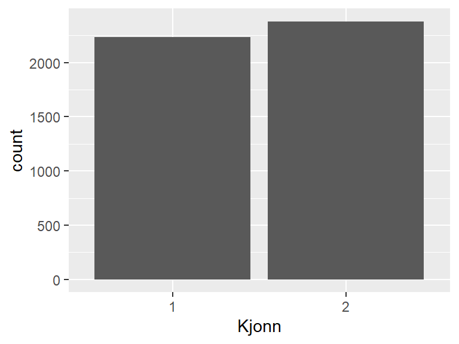

## Alder

*IOs alder*

| Feature | Result |
| --- | --- |
| Variable type | integer |
| Number of missing obs. | 0 (0 %) |
| Number of unique values | 64 |
| Median | 46 |
| 1st and 3rd quartiles | 31; 60 |
| Min. and max. | 16; 79 |

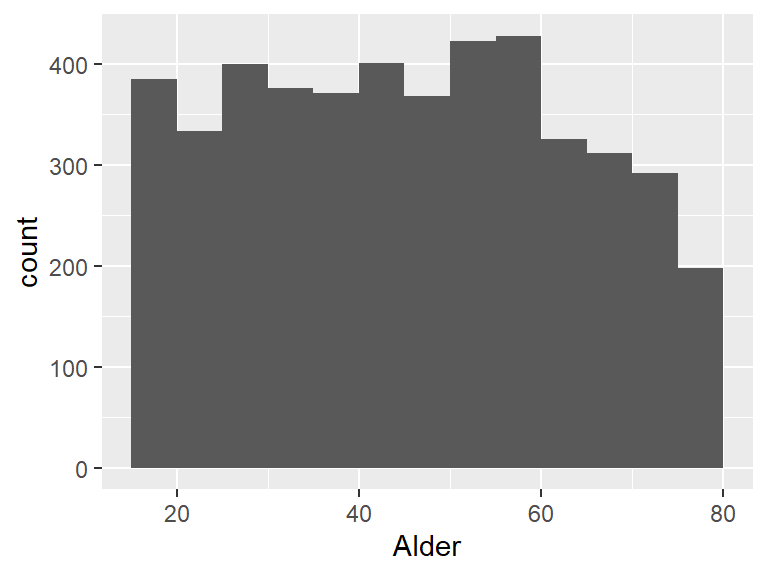

## sluttdato

*Dato for utfyllinga*

| Feature | Result |
| --- | --- |
| Variable type | integer |
| Number of missing obs. | 0 (0 %) |
| Number of unique values | 64 |
| Median | 13052025 |
| 1st and 3rd quartiles | 5062025; 22052025 |
| Min. and max. | 1062025; 31052025 |

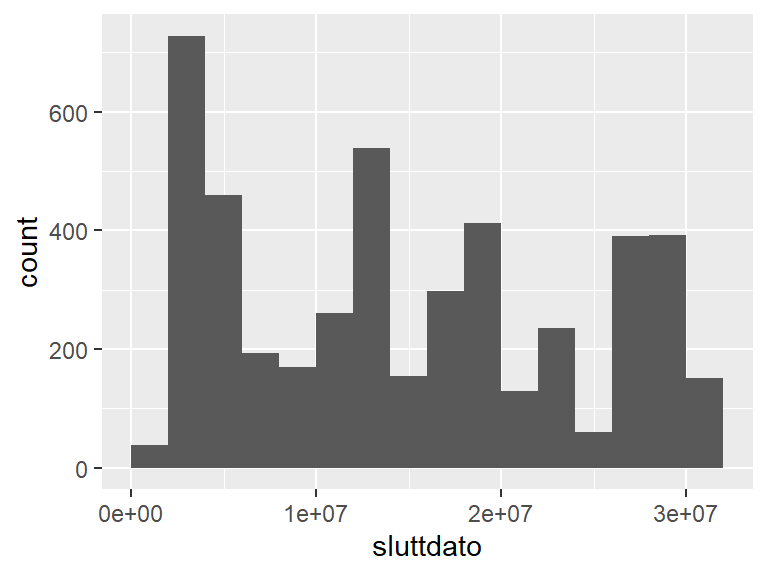

## Yrkesstatus

*Yrkesaktiv?*

| Feature | Result |
| --- | --- |
| Variable type | factor |
| Number of missing obs. | 0 (0 %) |
| Number of unique values | 4 |
| Mode | “1” |
| Reference category | 1 |

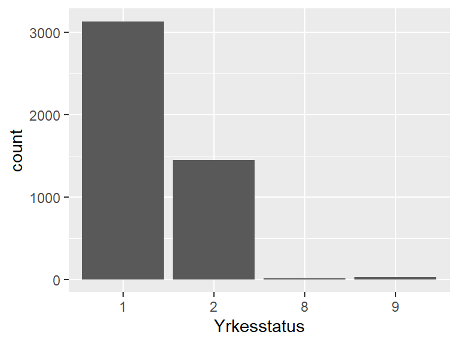

- The following suspected missing value codes enter as regular values: "8", "9".

## YrkStat2

*Yrkesstatus?.*

| Feature | Result |
| --- | --- |
| Variable type | factor |
| Number of missing obs. | 3168 (68.66 %) |
| Number of unique values | 10 |
| Mode | “3” |
| Reference category | 1 |

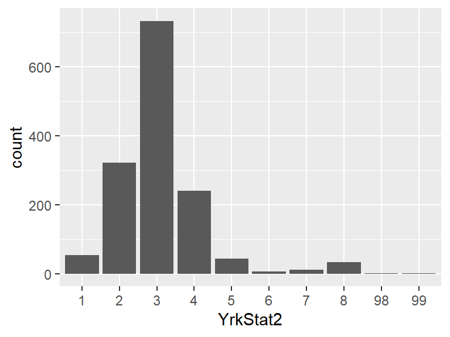

- The following suspected missing value codes enter as regular values: "8", "99".
- Note that the following levels have at most five observations: "98", "99".

## Siv

*Er du gift eller samboer?*

| Feature | Result |
| --- | --- |
| Variable type | factor |
| Number of missing obs. | 0 (0 %) |
| Number of unique values | 5 |
| Mode | “1” |
| Reference category | 1 |

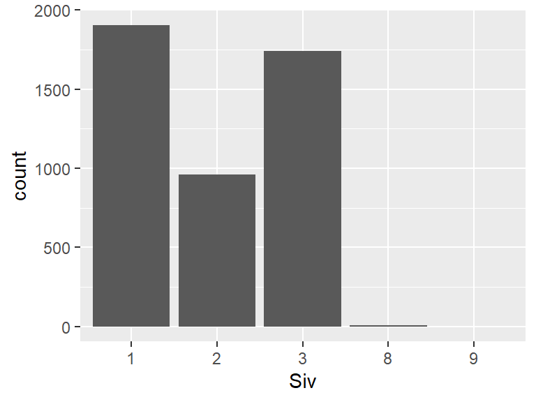

- The following suspected missing value codes enter as regular values: "8", "9".
- Note that the following levels have at most five observations: "9".

## SivStat

*IOs formelle sivilstatus*

| Feature | Result |
| --- | --- |
| Variable type | factor |
| Number of missing obs. | 1906 (41.31 %) |
| Number of unique values | 7 |
| Mode | “1” |
| Reference category | 1 |

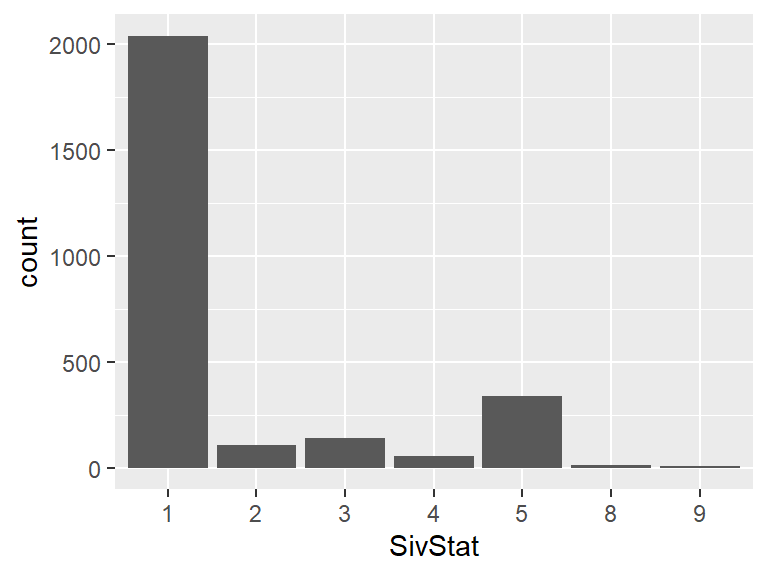

- The following suspected missing value codes enter as regular values: "8", "9".

## Antpers

*Antall medlemmer i husholdningen?*

| Feature | Result |
| --- | --- |
| Variable type | integer |
| Number of missing obs. | 0 (0 %) |
| Number of unique values | 11 |
| Median | 2 |
| 1st and 3rd quartiles | 2; 4 |
| Min. and max. | 1; 98 |

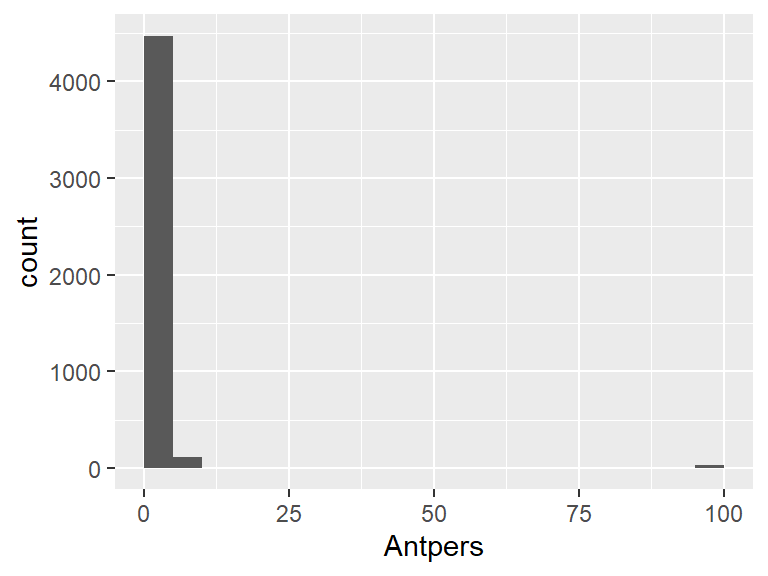

- Note that the following possible outlier values were detected: "1", "98".

## AntBarn1

*Antall barn under 6 år.*

| Feature | Result |
| --- | --- |
| Variable type | integer |
| Number of missing obs. | 1095 (23.73 %) |
| Number of unique values | 7 |
| Median | 0 |
| 1st and 3rd quartiles | 0; 0 |
| Min. and max. | 0; 99 |

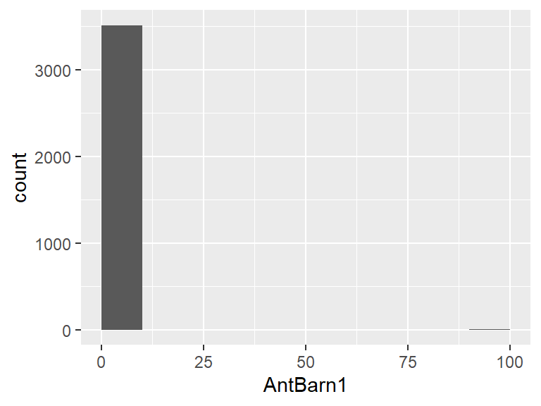

- Note that the following possible outlier values were detected: "1", "2", "3", "4", "98", "99".

## AntBarn2

*Antall barn 6-18 år.*

| Feature | Result |
| --- | --- |
| Variable type | integer |
| Number of missing obs. | 1095 (23.73 %) |
| Number of unique values | 8 |
| Median | 0 |
| 1st and 3rd quartiles | 0; 1 |
| Min. and max. | 0; 98 |

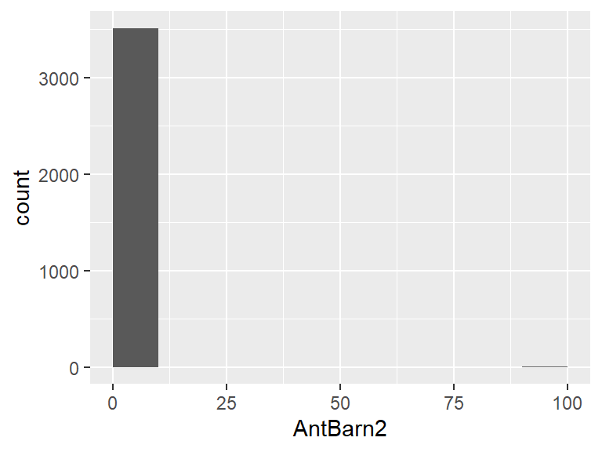

- Note that the following possible outlier values were detected: "98".

## Helse

*Egenopplevd helse.*

| Feature | Result |
| --- | --- |
| Variable type | factor |
| Number of missing obs. | 0 (0 %) |
| Number of unique values | 7 |
| Mode | “2” |
| Reference category | 1 |

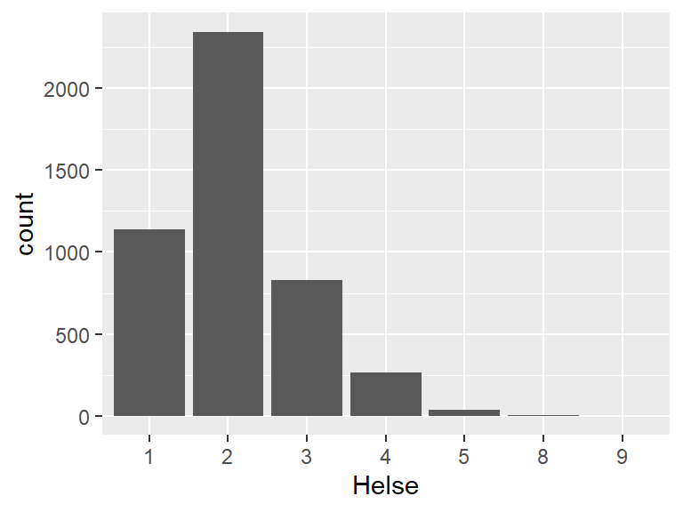

- The following suspected missing value codes enter as regular values: "8", "9".
- Note that the following levels have at most five observations: "9".

## Helsepsyk

*Egenopplevd psykisk helse.*

| Feature | Result |
| --- | --- |
| Variable type | factor |
| Number of missing obs. | 0 (0 %) |
| Number of unique values | 7 |
| Mode | “2” |
| Reference category | 1 |

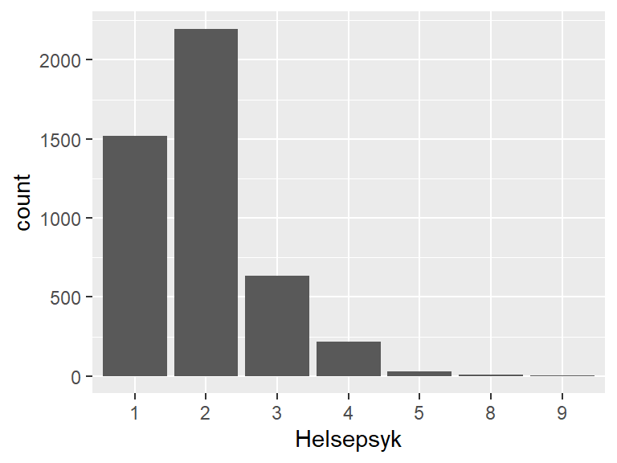

- The following suspected missing value codes enter as regular values: "8", "9".
- Note that the following levels have at most five observations: "9".

## Tob1

*Hender at røyker*

| Feature | Result |
| --- | --- |
| Variable type | factor |
| Number of missing obs. | 0 (0 %) |
| Number of unique values | 4 |
| Mode | “2” |
| Reference category | 1 |

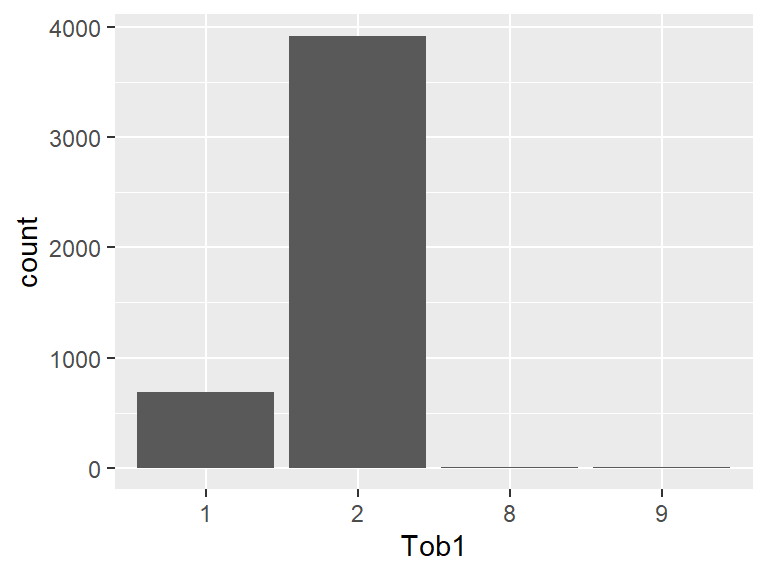

- The following suspected missing value codes enter as regular values: "8", "9".
- Note that the following levels have at most five observations: "8", "9".

## Tob2

*Røyker daglig/av og til?*

| Feature | Result |
| --- | --- |
| Variable type | factor |
| Number of missing obs. | 3926 (85.09 %) |
| Number of unique values | 3 |
| Mode | “2” |
| Reference category | 1 |

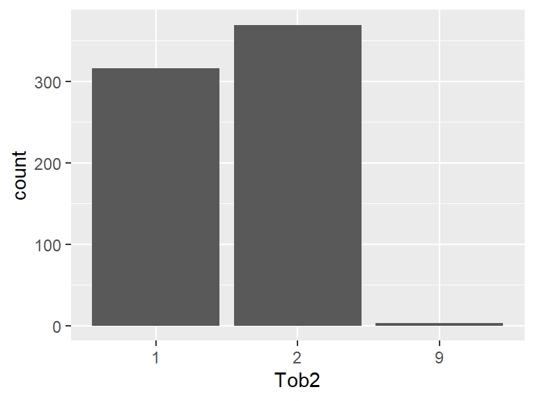

- The following suspected missing value codes enter as regular values: "9".
- Note that the following levels have at most five observations: "9".

## Tob3

*Røyker du sigaretter*

| Feature | Result |
| --- | --- |
| Variable type | factor |
| Number of missing obs. | 4245 (92 %) |
| Number of unique values | 4 |
| Mode | “1” |
| Reference category | 1 |

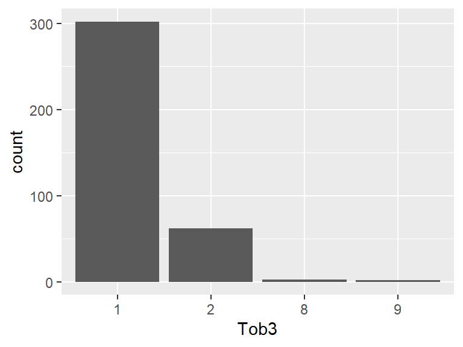

- The following suspected missing value codes enter as regular values: "8", "9".
- Note that the following levels have at most five observations: "8", "9".

## Tob4a

*Hvor mange sigaretter per uke*

| Feature | Result |
| --- | --- |
| Variable type | integer |
| Number of missing obs. | 4312 (93.45 %) |
| Number of unique values | 19 |
| Median | 1.5 |
| 1st and 3rd quartiles | 1; 5 |
| Min. and max. | 1; 999 |

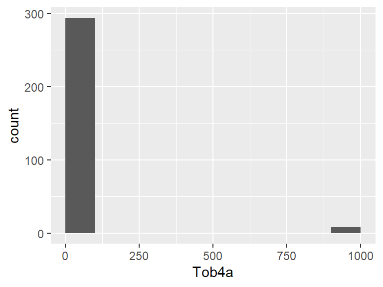

- The following suspected missing value codes enter as regular values: "999".
- Note that the following possible outlier values were detected: "80", "999".

## Tob5

*Hvor ofte røyker du sigaretter*

| Feature | Result |
| --- | --- |
| Variable type | factor |
| Number of missing obs. | 4312 (93.45 %) |
| Number of unique values | 4 |
| Mode | “3” |
| Reference category | 1 |

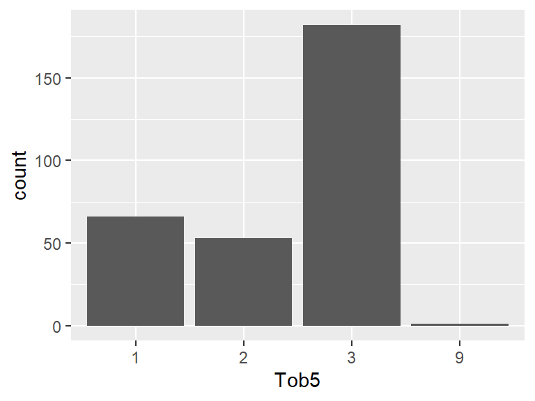

- The following suspected missing value codes enter as regular values: "9".
- Note that the following levels have at most five observations: "9".

## Tob13

*Har du noen gang røykt daglig?*

| Feature | Result |
| --- | --- |
| Variable type | factor |
| Number of missing obs. | 4245 (92 %) |
| Number of unique values | 4 |
| Mode | “1” |
| Reference category | 1 |

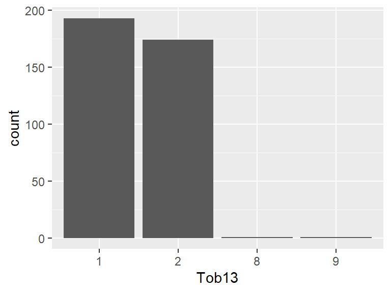

- The following suspected missing value codes enter as regular values: "8", "9".
- Note that the following levels have at most five observations: "8", "9".

## Tob14

*Har du noen gang røykt daglig eller av og til*

| Feature | Result |
| --- | --- |
| Variable type | factor |
| Number of missing obs. | 695 (15.06 %) |
| Number of unique values | 5 |
| Mode | “3” |
| Reference category | 1 |

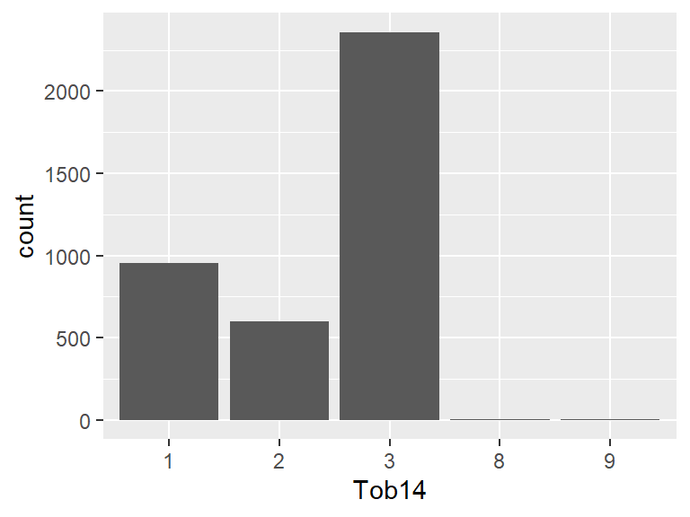

- The following suspected missing value codes enter as regular values: "8", "9".
- Note that the following levels have at most five observations: "8", "9".

## Tob20

*I hvilket år sluttet du å røyke daglig*

| Feature | Result |
| --- | --- |
| Variable type | integer |
| Number of missing obs. | 3469 (75.18 %) |
| Number of unique values | 62 |
| Median | 2010 |
| 1st and 3rd quartiles | 2001; 2018 |
| Min. and max. | 1948; 9999 |

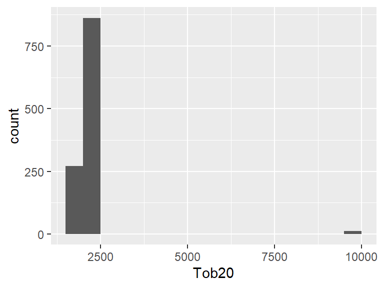

- Note that the following possible outlier values were detected: "1948", "1963", "1965", "9998", "9999".

## Tob21

*Hvor mange ganger forsøkte du å slutte å røyke daglig før du lyktes*

| Feature | Result |
| --- | --- |
| Variable type | integer |
| Number of missing obs. | 3469 (75.18 %) |
| Number of unique values | 21 |
| Median | 1 |
| 1st and 3rd quartiles | 0; 3 |
| Min. and max. | 0; 99 |

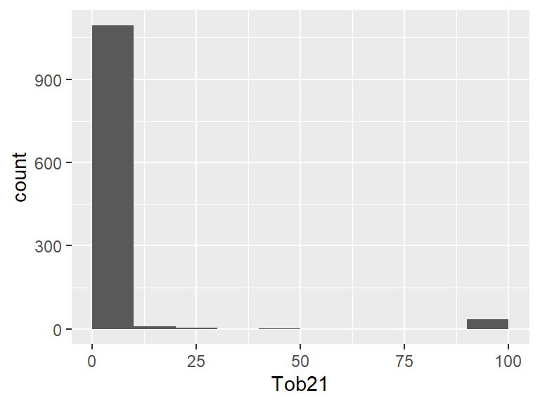

- Note that the following possible outlier values were detected: "50", "98", "99".

## Tob22a

*Sluttet siste gang - brukte snus*

| Feature | Result |
| --- | --- |
| Variable type | factor |
| Number of missing obs. | 4268 (92.5 %) |
| Number of unique values | 2 |
| Mode | “2” |
| Reference category | 1 |

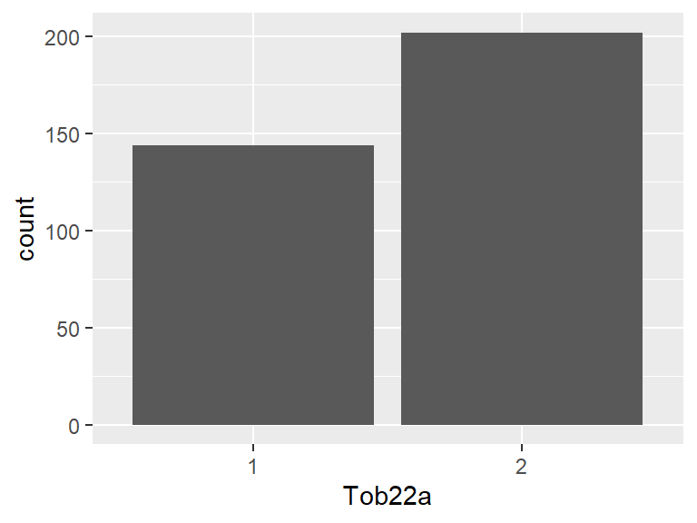

## Tob22b

*Sluttet siste gang - brukte nikotinlegemiddel*

| Feature | Result |
| --- | --- |
| Variable type | factor |
| Number of missing obs. | 4268 (92.5 %) |
| Number of unique values | 2 |
| Mode | “2” |
| Reference category | 1 |

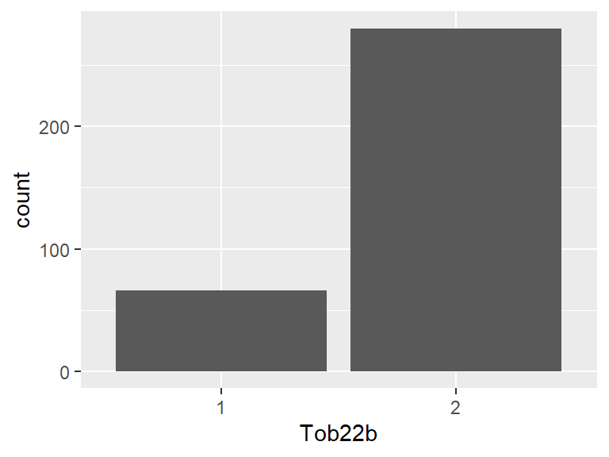

## Tob22d

*Sluttet siste gang - brukte røykeavvenningsprodukt*

| Feature | Result |
| --- | --- |
| Variable type | factor |
| Number of missing obs. | 4268 (92.5 %) |
| Number of unique values | 2 |
| Mode | “2” |
| Reference category | 1 |

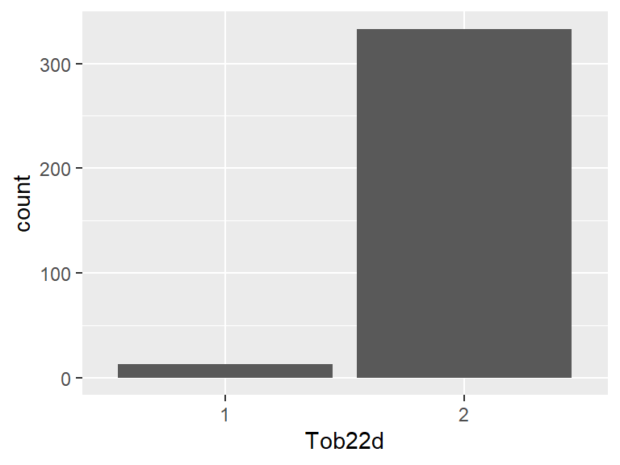

## Tob22q

*Sluttet siste gang - søkte helsetjenesten*

| Feature | Result |
| --- | --- |
| Variable type | factor |
| Number of missing obs. | 4268 (92.5 %) |
| Number of unique values | 2 |
| Mode | “2” |
| Reference category | 1 |

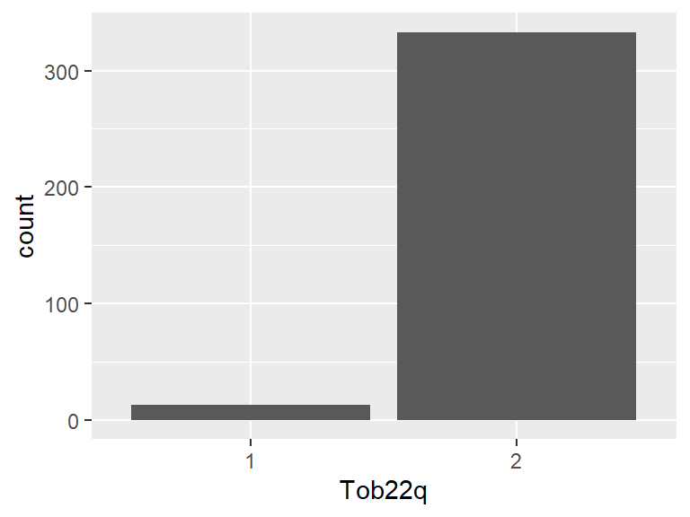

## Tob22s

*Sluttet siste gang - brukte e-sigaretter*

| Feature | Result |
| --- | --- |
| Variable type | factor |
| Number of missing obs. | 4268 (92.5 %) |
| Number of unique values | 2 |
| Mode | “2” |
| Reference category | 1 |

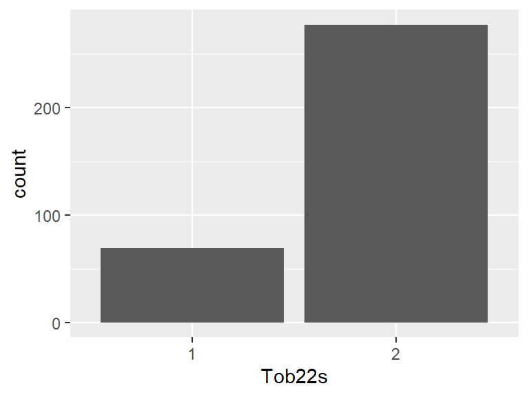

## Tob22r

*Sluttet siste gang - søkte nettsider eller mobiltjenester for røykeslutt*

| Feature | Result |
| --- | --- |
| Variable type | factor |
| Number of missing obs. | 4268 (92.5 %) |
| Number of unique values | 2 |
| Mode | “2” |
| Reference category | 1 |

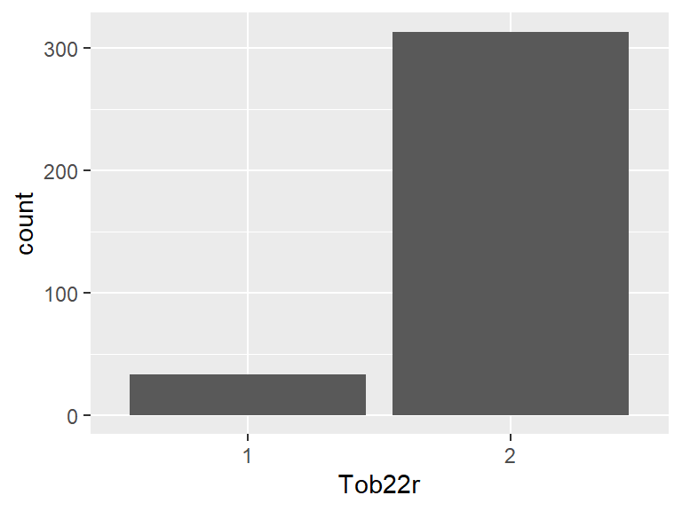

## Tob23

*Hvor gammel var du da du begynte å røyke daglig*

| Feature | Result |
| --- | --- |
| Variable type | integer |
| Number of missing obs. | 3153 (68.34 %) |
| Number of unique values | 38 |
| Median | 17 |
| 1st and 3rd quartiles | 15; 19 |
| Min. and max. | 9; 99 |

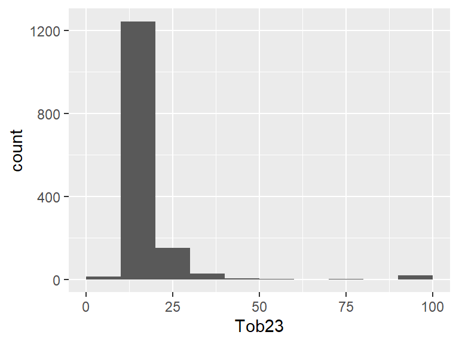

- Note that the following possible outlier values were detected: "26", "27", "28", "29", "30", "32", "34", "35", "36", "38", "39", "40", "41", "45", "50", "51", "52", "60", "79", "98", "99".

## Tob30

*Røyker du sigaretter daglig*

| Feature | Result |
| --- | --- |
| Variable type | factor |
| Number of missing obs. | 4298 (93.15 %) |
| Number of unique values | 2 |
| Mode | “1” |
| Reference category | 1 |

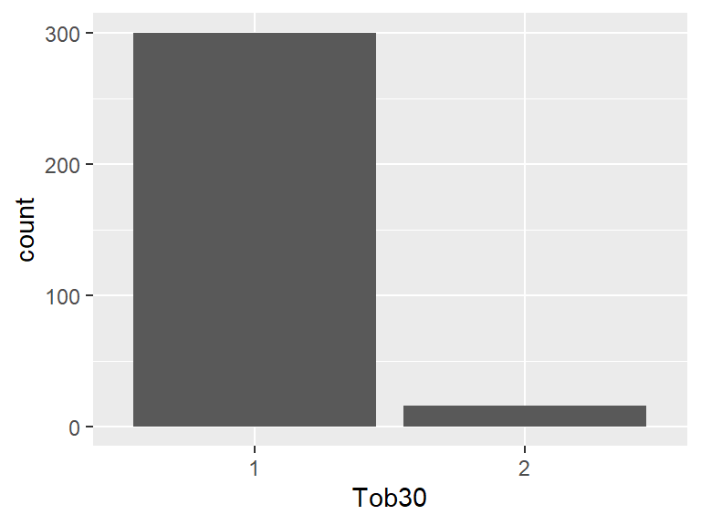

## Tob31a

*Hvor mange sigaretter røyker du gjennomsnittlig pr. dag*

| Feature | Result |
| --- | --- |
| Variable type | integer |
| Number of missing obs. | 4314 (93.5 %) |
| Number of unique values | 24 |
| Median | 10 |
| 1st and 3rd quartiles | 7; 15 |
| Min. and max. | 1; 999 |

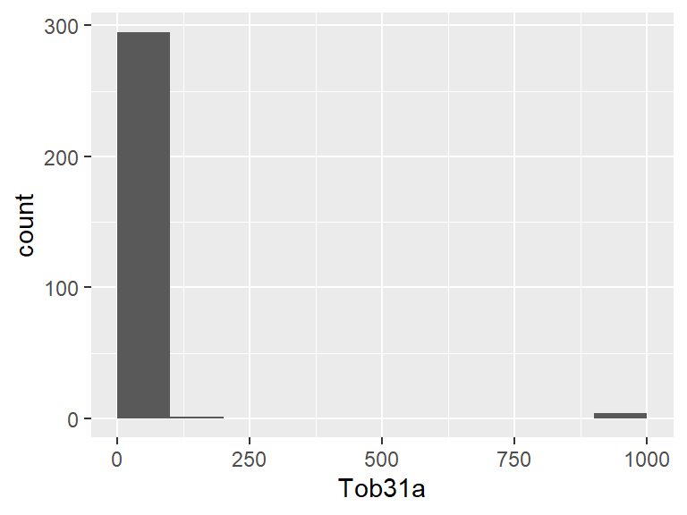

- Note that the following possible outlier values were detected: "1", "2", "200", "998", "999".

## Tob31b

*Hvor mange av disse sigarettene er fabrikklagde*

| Feature | Result |
| --- | --- |
| Variable type | integer |
| Number of missing obs. | 4314 (93.5 %) |
| Number of unique values | 22 |
| Median | 10 |
| 1st and 3rd quartiles | 4.75; 15 |
| Min. and max. | 0; 999 |

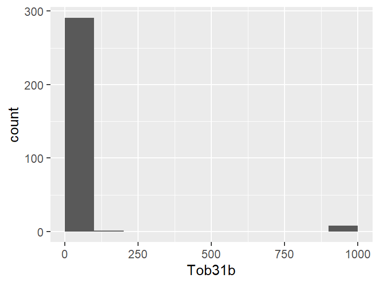

- Note that the following possible outlier values were detected: "200", "998", "999".

## Tob31c

*Hvor mange av disse sigarettene er hjemmerullede*

| Feature | Result |
| --- | --- |
| Variable type | integer |
| Number of missing obs. | 4314 (93.5 %) |
| Number of unique values | 20 |
| Median | 0 |
| 1st and 3rd quartiles | 0; 0 |
| Min. and max. | 0; 999 |

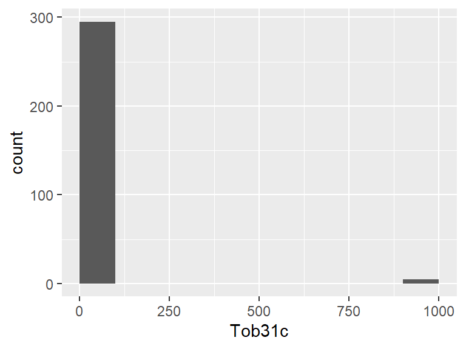

- Note that the following possible outlier values were detected: "1", "2", "3", "4", "5", "6", "7", "8", "9", "10", "11", "12", "14", "15", "20", "25", "30", "998", "999".

## Tob33

*Røyker du sigarer eller sigarillos daglig, av og til eller aldri*

| Feature | Result |
| --- | --- |
| Variable type | factor |
| Number of missing obs. | 3926 (85.09 %) |
| Number of unique values | 5 |
| Mode | “3” |
| Reference category | 1 |

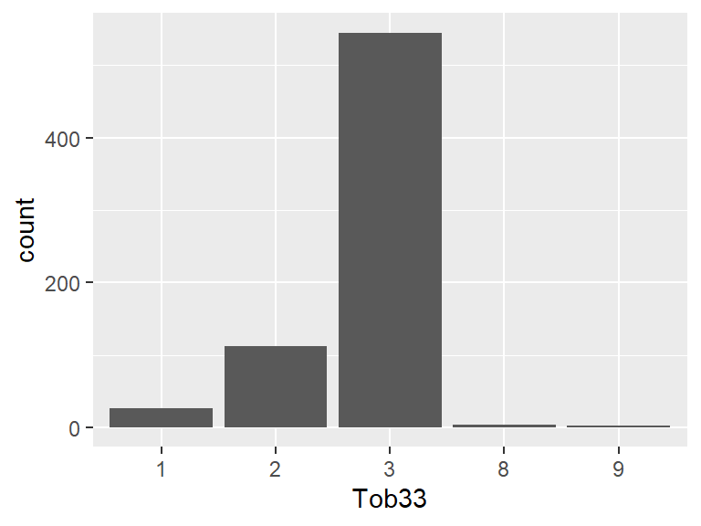

- The following suspected missing value codes enter as regular values: "8", "9".
- Note that the following levels have at most five observations: "8", "9".

## Tob34

*Røyker du pipe daglig, av og til eller aldri?*

| Feature | Result |
| --- | --- |
| Variable type | factor |
| Number of missing obs. | 3926 (85.09 %) |
| Number of unique values | 5 |
| Mode | “3” |
| Reference category | 1 |

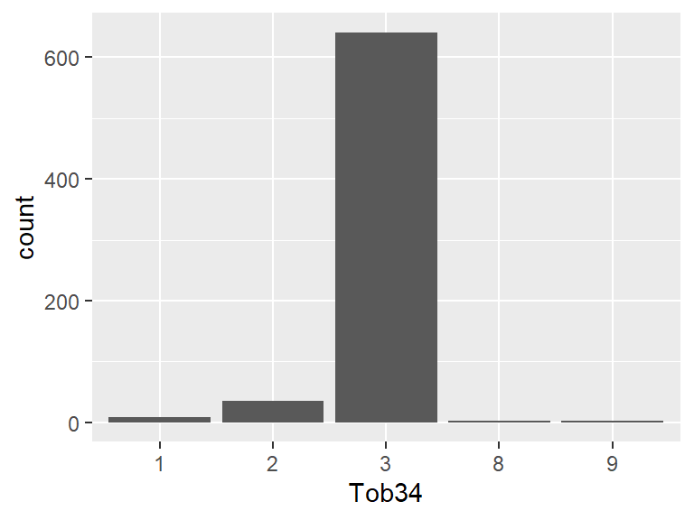

- The following suspected missing value codes enter as regular values: "8", "9".
- Note that the following levels have at most five observations: "8", "9".

## Tob38

*Har du noen gang prøvd å slutte å røyke daglig?*

| Feature | Result |
| --- | --- |
| Variable type | factor |
| Number of missing obs. | 4298 (93.15 %) |
| Number of unique values | 4 |
| Mode | “1” |
| Reference category | 1 |

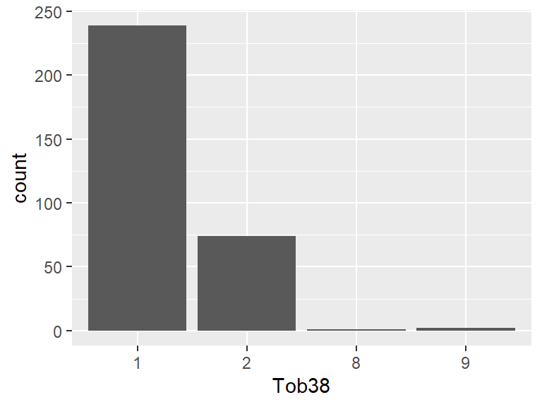

- The following suspected missing value codes enter as regular values: "8", "9".
- Note that the following levels have at most five observations: "8", "9".

## Tob39

*Hvor mange ganger totalt har du prøvd å slutte å røyke daglig?*

| Feature | Result |
| --- | --- |
| Variable type | integer |
| Number of missing obs. | 4375 (94.82 %) |
| Number of unique values | 16 |
| Median | 3 |
| 1st and 3rd quartiles | 2; 5 |
| Min. and max. | 1; 99 |

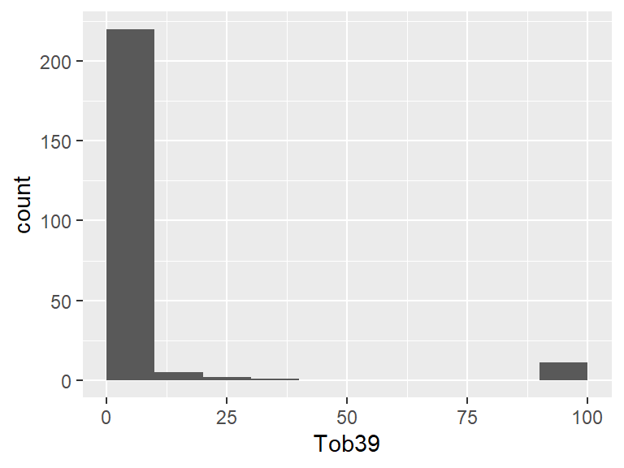

- The following suspected missing value codes enter as regular values: "99".
- Note that the following possible outlier values were detected: "20", "30", "40", "97", "99".

## Tob40

*Har du prøvd å slutte å røyke daglig i løpet av de siste 12 månedene?*

| Feature | Result |
| --- | --- |
| Variable type | factor |
| Number of missing obs. | 4375 (94.82 %) |
| Number of unique values | 2 |
| Mode | “2” |
| Reference category | 1 |

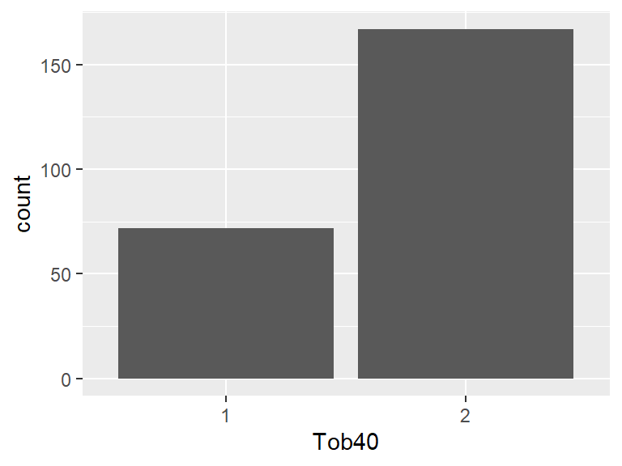

## Tob42a

*Forsøkte å slutte siste gang … brukte snus*

| Feature | Result |
| --- | --- |
| Variable type | factor |
| Number of missing obs. | 4375 (94.82 %) |
| Number of unique values | 2 |
| Mode | “2” |
| Reference category | 1 |

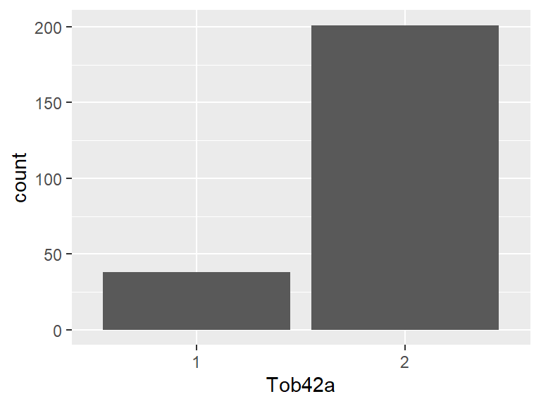

## Tob42b

*Forsøkte å slutte siste gang … brukte nikotinlegemiddel*

| Feature | Result |
| --- | --- |
| Variable type | factor |
| Number of missing obs. | 4375 (94.82 %) |
| Number of unique values | 2 |
| Mode | “2” |
| Reference category | 1 |

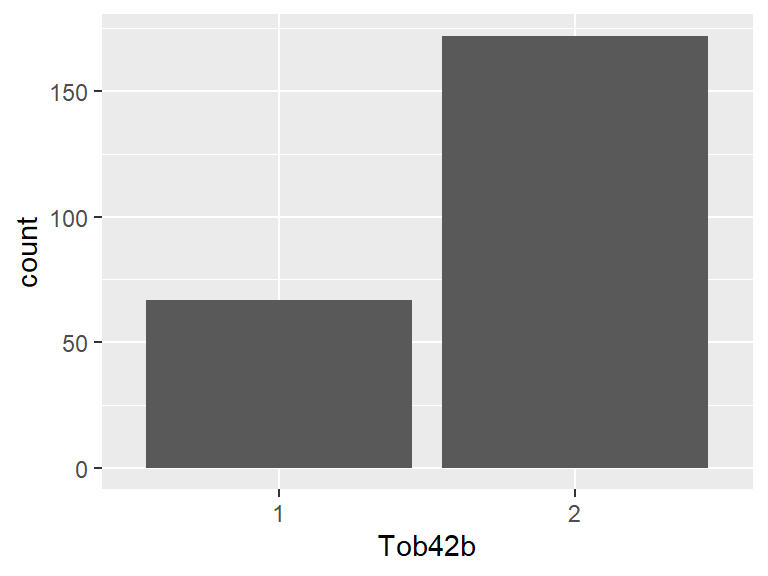

## Tob42d

*Forsøkte å slutte siste gang … brukte reseptbelagt røykeavvenningsprodukt*

| Feature | Result |
| --- | --- |
| Variable type | factor |
| Number of missing obs. | 4375 (94.82 %) |
| Number of unique values | 3 |
| Mode | “2” |
| Reference category | 1 |

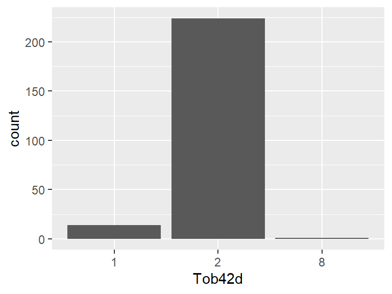

- The following suspected missing value codes enter as regular values: "8".
- Note that the following levels have at most five observations: "8".

## Tob42o

*Forsøkte å slutte siste gang … brukte elektroniske sigaretter*

| Feature | Result |
| --- | --- |
| Variable type | factor |
| Number of missing obs. | 4375 (94.82 %) |
| Number of unique values | 2 |
| Mode | “2” |
| Reference category | 1 |

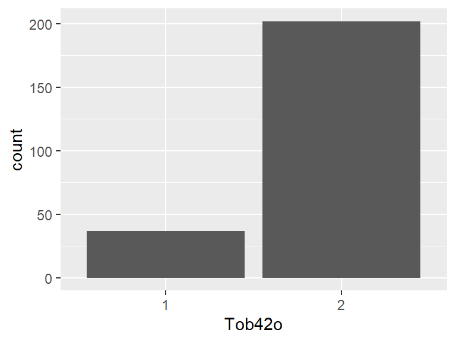

## Tob42m

*Forsøkte å slutte siste gang … søkte hjelp i helsetjenesten/kommunen*

| Feature | Result |
| --- | --- |
| Variable type | factor |
| Number of missing obs. | 4375 (94.82 %) |
| Number of unique values | 2 |
| Mode | “2” |
| Reference category | 1 |

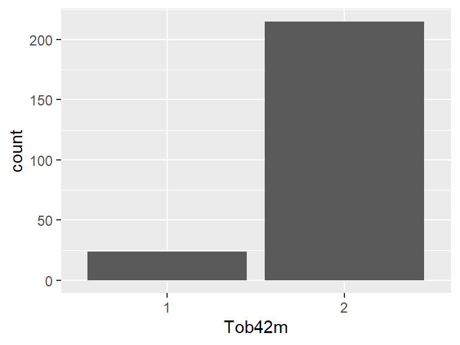

## Tob42n

*Forsøkte å slutte siste gang … søkte hjelp på nettsider eller mobiltjenester for røykeslutt*

| Feature | Result |
| --- | --- |
| Variable type | factor |
| Number of missing obs. | 4375 (94.82 %) |
| Number of unique values | 2 |
| Mode | “2” |
| Reference category | 1 |

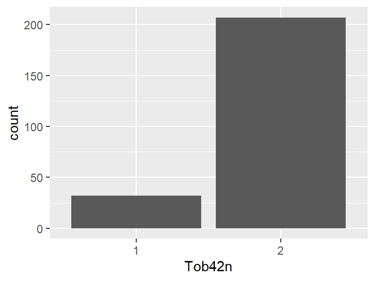

## Tob43

*Vurderer du seriøst å slutte å røyke de neste 6 månedene?*

| Feature | Result |
| --- | --- |
| Variable type | factor |
| Number of missing obs. | 3926 (85.09 %) |
| Number of unique values | 4 |
| Mode | “2” |
| Reference category | 1 |

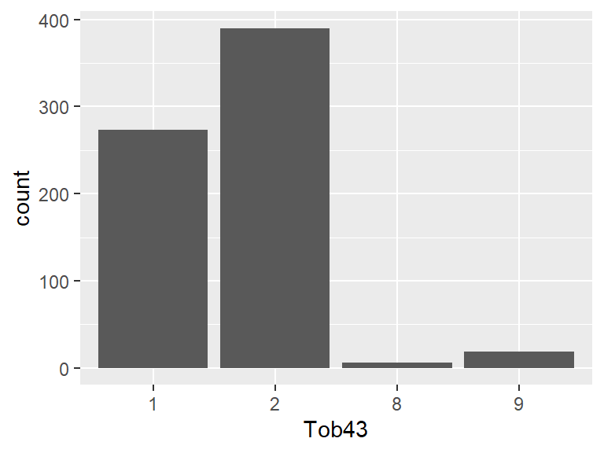

- The following suspected missing value codes enter as regular values: "8", "9".

## Tob44

*Planlegger du å slutte å røyke i løpet av de neste 30 dagene?*

| Feature | Result |
| --- | --- |
| Variable type | factor |
| Number of missing obs. | 4341 (94.08 %) |
| Number of unique values | 3 |
| Mode | “2” |
| Reference category | 1 |

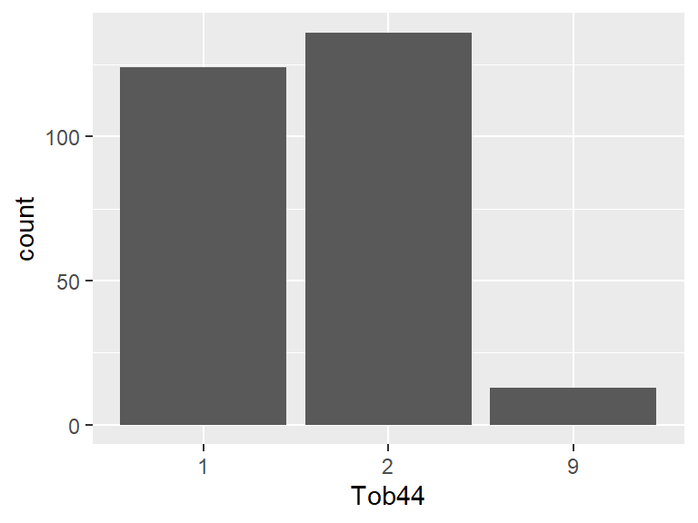

- The following suspected missing value codes enter as regular values: "9".

## Tobvan1

*Hvor lang tid etter at du våkner, tenner du din første sigarett*

| Feature | Result |
| --- | --- |
| Variable type | factor |
| Number of missing obs. | 4341 (94.08 %) |
| Number of unique values | 6 |
| Mode | “4” |
| Reference category | 1 |

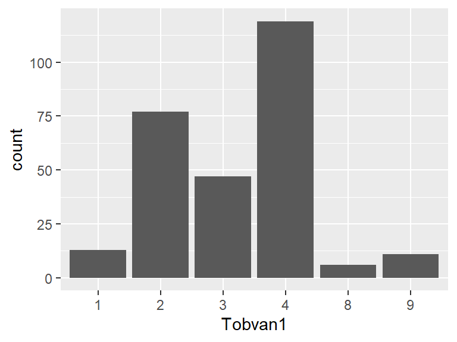

- The following suspected missing value codes enter as regular values: "8", "9".

## Tob61

*Kan du prøve å forutsi dine røykevaner omkring 5 år fra nå?*

| Feature | Result |
| --- | --- |
| Variable type | factor |
| Number of missing obs. | 0 (0 %) |
| Number of unique values | 6 |
| Mode | “4” |
| Reference category | 1 |

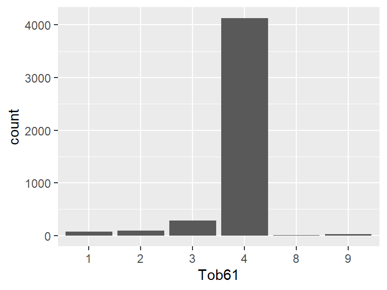

- The following suspected missing value codes enter as regular values: "8", "9".

## Tob61b

*Kan du prøve å forutsi dine snusvaner omkring 5 år fra nå?*

| Feature | Result |
| --- | --- |
| Variable type | factor |
| Number of missing obs. | 0 (0 %) |
| Number of unique values | 6 |
| Mode | “4” |
| Reference category | 1 |

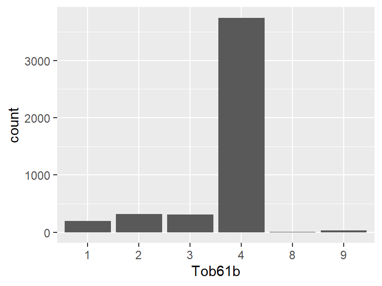

- The following suspected missing value codes enter as regular values: "8", "9".

## Tob62a

*Hvor skadelig tror du snus er på en skala fra 1 til 7*

| Feature | Result |
| --- | --- |
| Variable type | factor |
| Number of missing obs. | 0 (0 %) |
| Number of unique values | 9 |
| Mode | “5” |
| Reference category | 1 |

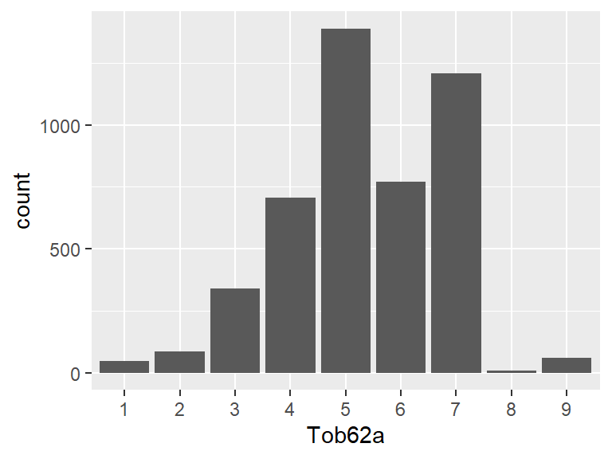

- The following suspected missing value codes enter as regular values: "8", "9".

## Tob62e

*Hvor skadelig tror du ferdigsigaretter med lavere nikotin- og tjæreinnhold er, på en skala fra 1 til 7?*

| Feature | Result |
| --- | --- |
| Variable type | factor |
| Number of missing obs. | 0 (0 %) |
| Number of unique values | 9 |
| Mode | “7” |
| Reference category | 1 |

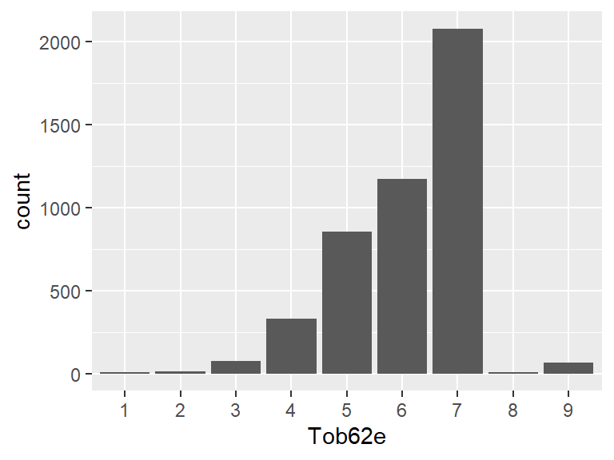

- The following suspected missing value codes enter as regular values: "8", "9".

## Tob62f

*Hvor skadelig tror du vanlige ferdigsigaretter er, på en skala fra 1 til 7?*

| Feature | Result |
| --- | --- |
| Variable type | factor |
| Number of missing obs. | 0 (0 %) |
| Number of unique values | 9 |
| Mode | “7” |
| Reference category | 1 |

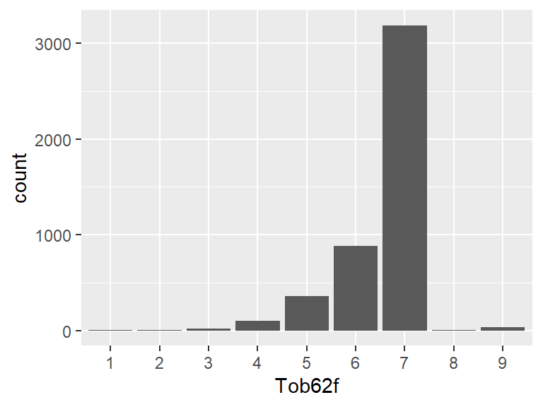

- The following suspected missing value codes enter as regular values: "8", "9".

## Tob62g

*Hvor skadelig tror du produkter som er laget for å erstatte tobakksprodukter med nikotin, som for eksempel nikotintyggegummi, nikotinplaster og nikotinposer er, på en skala fra 1 til 7?*

| Feature | Result |
| --- | --- |
| Variable type | factor |
| Number of missing obs. | 0 (0 %) |
| Number of unique values | 9 |
| Mode | “4” |
| Reference category | 1 |

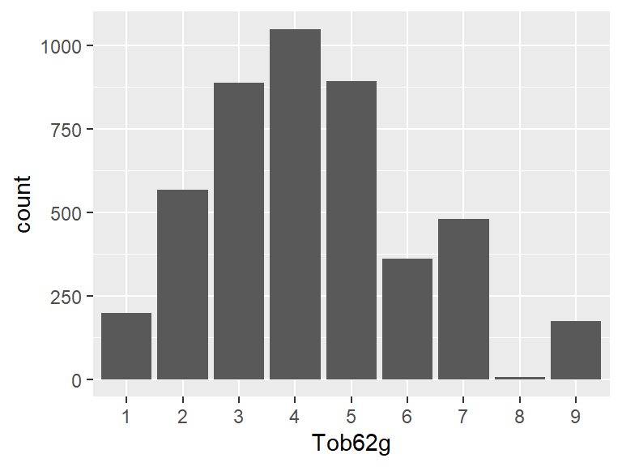

- The following suspected missing value codes enter as regular values: "8", "9".

## Tob62h

*Hvor skadelig tror du e-sigaretter/fordampere (vape) er, på en skala fra 1 til 7?*

| Feature | Result |
| --- | --- |
| Variable type | factor |
| Number of missing obs. | 0 (0 %) |
| Number of unique values | 9 |
| Mode | “7” |
| Reference category | 1 |

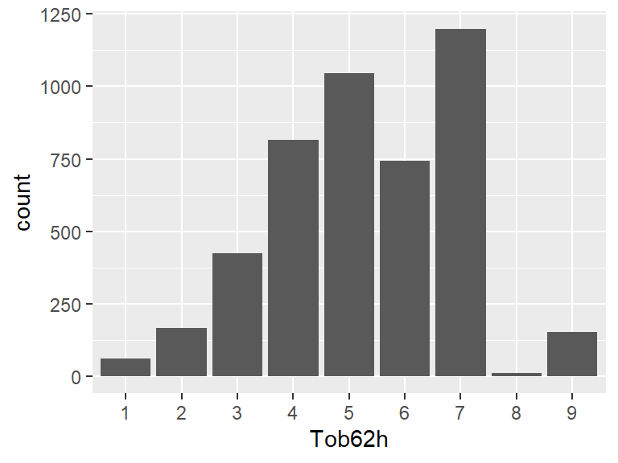

- The following suspected missing value codes enter as regular values: "8", "9".

## TobE

*Bruker du e-sigaretter/fordampere daglig, av og til eller aldri?*

| Feature | Result |
| --- | --- |
| Variable type | factor |
| Number of missing obs. | 0 (0 %) |
| Number of unique values | 5 |
| Mode | “3” |
| Reference category | 1 |

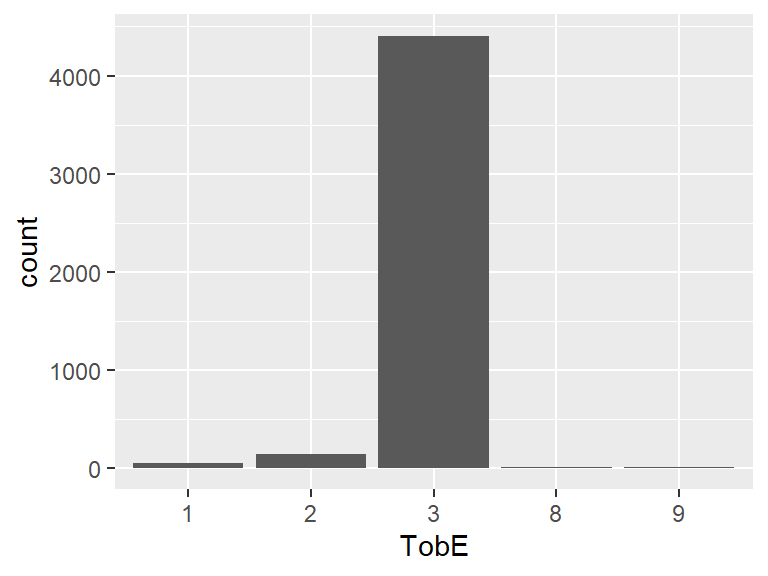

- The following suspected missing value codes enter as regular values: "8", "9".

## TobE1

*Har du tidligere brukt e-sigaretter/fordampere?*

| Feature | Result |
| --- | --- |
| Variable type | factor |
| Number of missing obs. | 208 (4.51 %) |
| Number of unique values | 5 |
| Mode | “3” |
| Reference category | 1 |

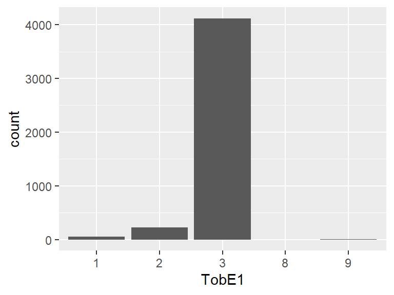

- The following suspected missing value codes enter as regular values: "8", "9".
- Note that the following levels have at most five observations: "8", "9".

## tobald

*Hvor gammel var du da du begynte å bruke e-sigaretter regelmessig? Alder:*

| Feature | Result |
| --- | --- |
| Variable type | integer |
| Number of missing obs. | 4141 (89.75 %) |
| Number of unique values | 61 |
| Median | 31 |
| 1st and 3rd quartiles | 19; 50 |
| Min. and max. | 5; 999 |

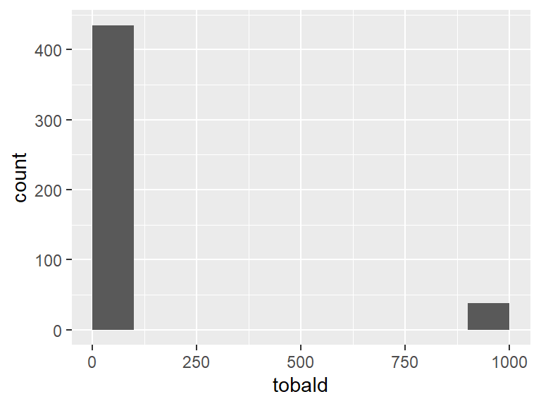

- Note that the following possible outlier values were detected: "998", "999".

## TobE3

*Hvilken type e-sigaretter/fordamper bruker du/brukte du i hovedsak?*

| Feature | Result |
| --- | --- |
| Variable type | factor |
| Number of missing obs. | 4141 (89.75 %) |
| Number of unique values | 5 |
| Mode | “1” |
| Reference category | 1 |

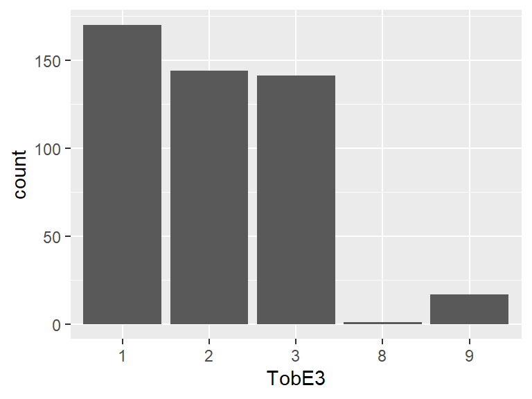

- The following suspected missing value codes enter as regular values: "8", "9".
- Note that the following levels have at most five observations: "8".

## TobE4

*Hva er/var nikotininnholdet i væsken i de e-sigarettene du vanligvis bruker/brukte?*

| Feature | Result |
| --- | --- |
| Variable type | factor |
| Number of missing obs. | 4141 (89.75 %) |
| Number of unique values | 7 |
| Mode | “7” |
| Reference category | 1 |

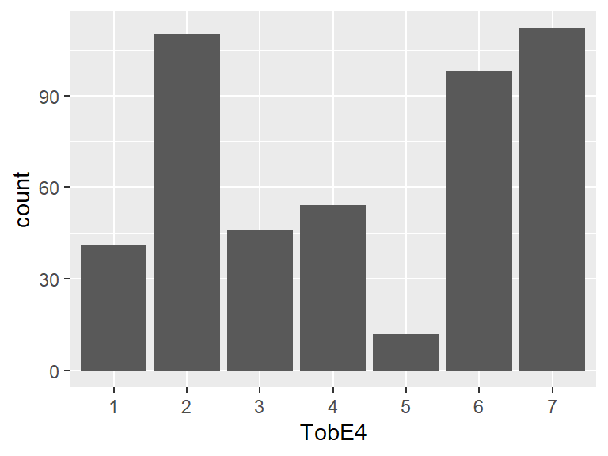

## Tob60

*Bruker du snus daglig, av og til eller aldri*

| Feature | Result |
| --- | --- |
| Variable type | factor |
| Number of missing obs. | 0 (0 %) |
| Number of unique values | 5 |
| Mode | “3” |
| Reference category | 1 |

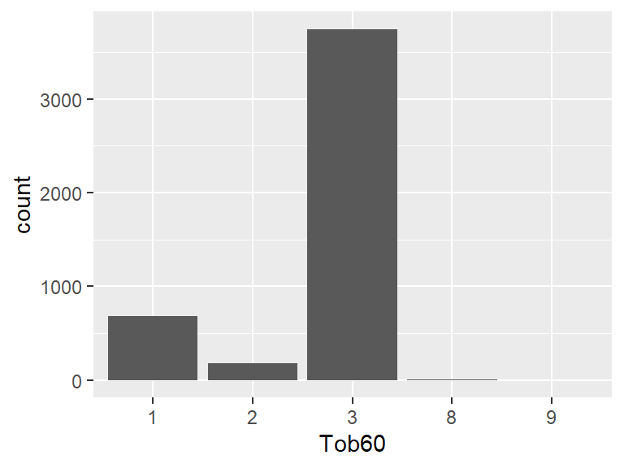

- The following suspected missing value codes enter as regular values: "8", "9".
- Note that the following levels have at most five observations: "9".

## Tob64a

*Har du brukt snus tidligere?*

| Feature | Result |
| --- | --- |
| Variable type | factor |
| Number of missing obs. | 869 (18.83 %) |
| Number of unique values | 4 |
| Mode | “2” |
| Reference category | 1 |

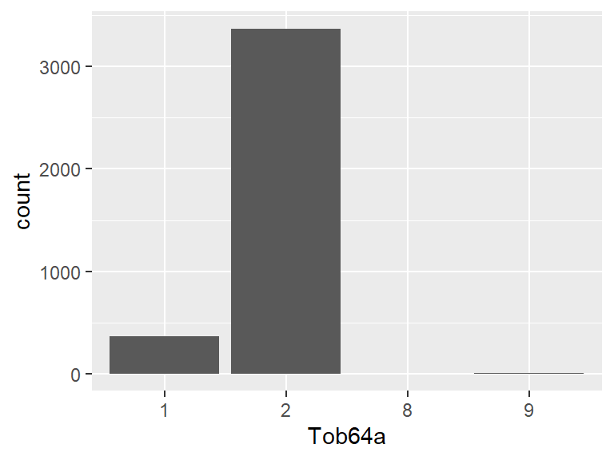

- The following suspected missing value codes enter as regular values: "8", "9".
- Note that the following levels have at most five observations: "8", "9".

## Tob64b

*Brukte du snus daglig eller av og til?*

| Feature | Result |
| --- | --- |
| Variable type | factor |
| Number of missing obs. | 4245 (92 %) |
| Number of unique values | 4 |
| Mode | “1” |
| Reference category | 1 |

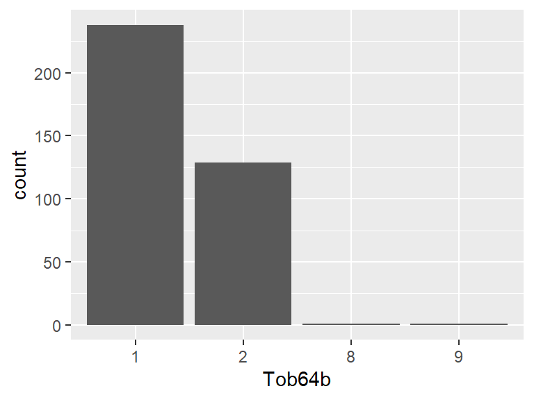

- The following suspected missing value codes enter as regular values: "8", "9".
- Note that the following levels have at most five observations: "8", "9".

## Tob64c

*Har du tidligere brukt snus daglig?*

| Feature | Result |
| --- | --- |
| Variable type | factor |
| Number of missing obs. | 4431 (96.03 %) |
| Number of unique values | 2 |
| Mode | “2” |
| Reference category | 1 |

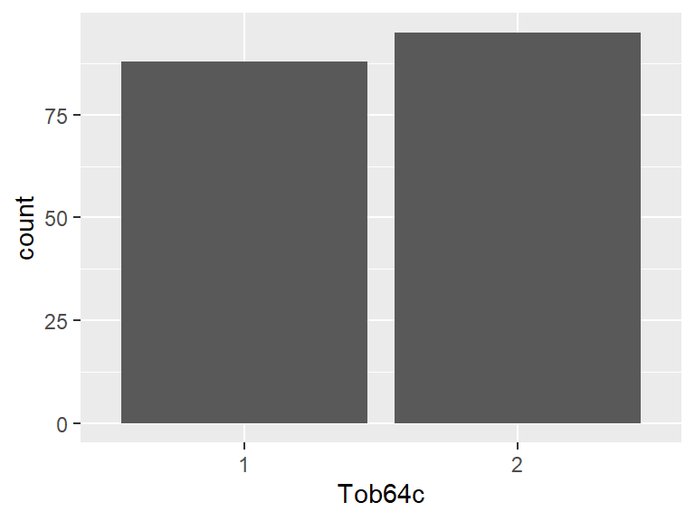